# R Markdown with Tabs

Wu Gong

2022-05-23

## Level I Tab A

- A R markdown template that outputs a structure of hiercharical tabs

## Tab B

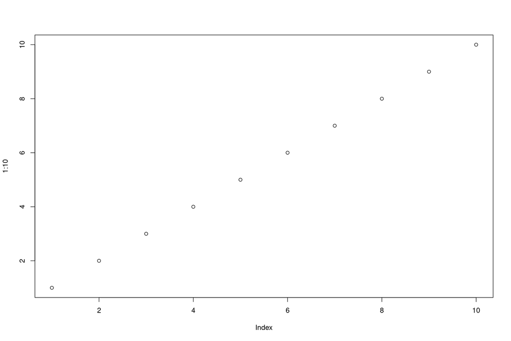

## Tab C

| var1 | var2 |
| --- | --- |
| 1 | 11 |
| 2 | 12 |
| 3 | 13 |
| 4 | 14 |
| 5 | 15 |
| 6 | 16 |
| 7 | 17 |
| 8 | 18 |
| 9 | 19 |
| 10 | 20 |

## Tab D

### Tab I

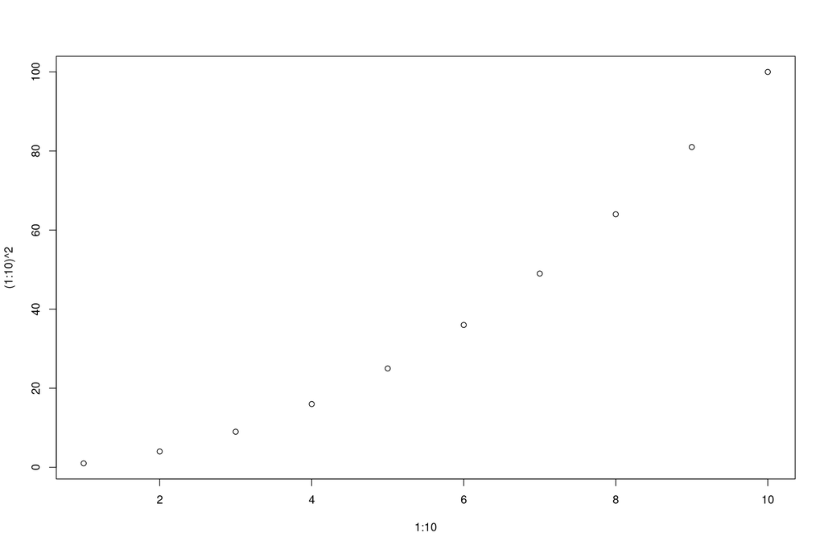

### Tab II

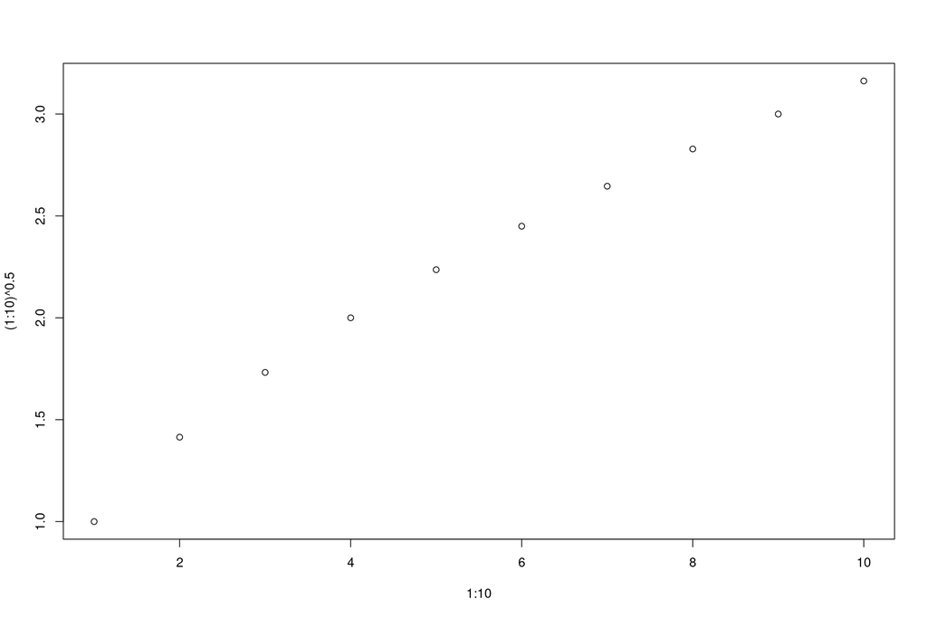

### Tab III

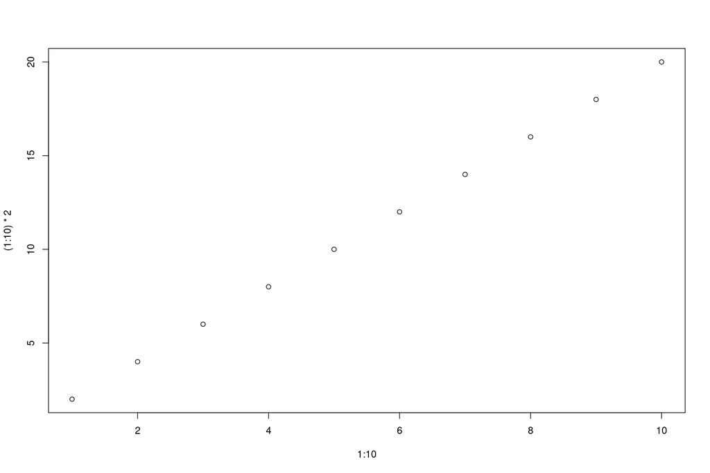

## About

[Wu Gong](https://ghowoo.github.io/)

[1] “2022-05-23”

R version 4.1.2 (2021-11-01) Platform: x86_64-pc-linux-gnu (64-bit) Running under: Ubuntu 20.04.3 LTS

Matrix products: default BLAS: /usr/lib/x86_64-linux-gnu/blas/libblas.so.3.9.0 LAPACK: /usr/lib/x86_64-linux-gnu/lapack/liblapack.so.3.9.0

attached base packages: [1] stats graphics grDevices utils datasets methods base